# Solutions for 08/09. Introduction to multiple regression

Notes and in-class exercises

```r
# Load packages
library(readr)
library(ggplot2)
library(dplyr)

# Load data
library(palmerpenguins)
data(penguins)
penguins <- penguins %>%
  filter(species != "Adelie", bill_length_mm < 57)

# Check it out
head(penguins)
```

```
# A tibble: 6 × 8
  species island bill_length_mm bill_depth_mm flipper_length_mm body_mass_g
  <fct>   <fct>           <dbl>         <dbl>             <int>       <int>
1 Gentoo  Biscoe           46.1          13.2               211        4500
2 Gentoo  Biscoe           50            16.3               230        5700
3 Gentoo  Biscoe           48.7          14.1               210        4450
4 Gentoo  Biscoe           50            15.2               218        5700
5 Gentoo  Biscoe           47.6          14.5               215        5400
6 Gentoo  Biscoe           46.5          13.5               210        4550
# ℹ 2 more variables: sex <fct>, year <int>
```

## Review Exercise 1: Visualizing bivariate relationships

Consider two potential predictors of flipper length: a penguin’s bill length, and the species of penguin.

Let’s first visualize how each of these predictors is related to flipper length:

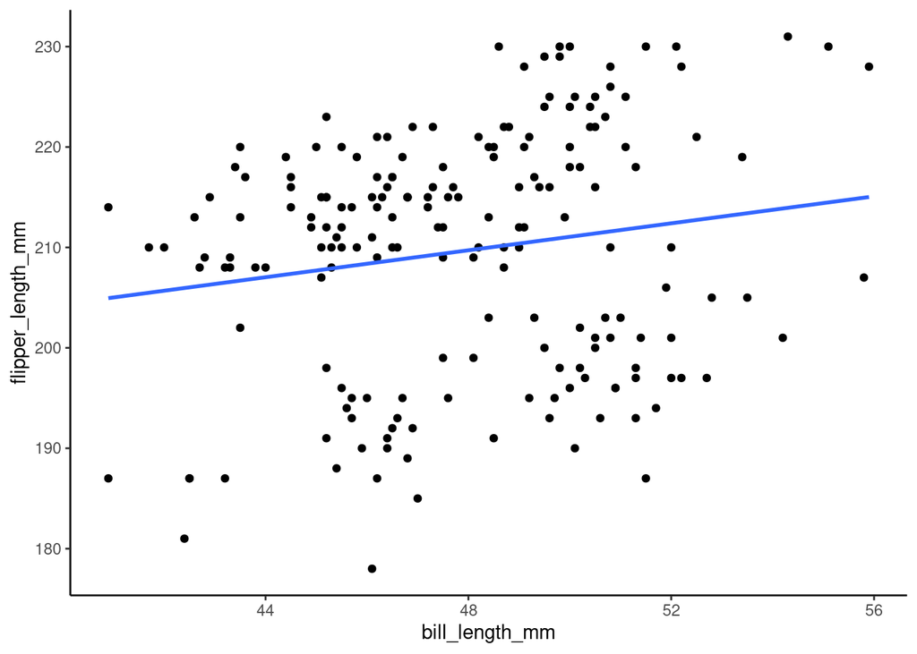

```r
penguins %>%
  ggplot(aes(y = flipper_length_mm, x = bill_length_mm)) +
  geom_point() +
  geom_smooth(method = "lm", se = FALSE)+
  theme_classic()
```

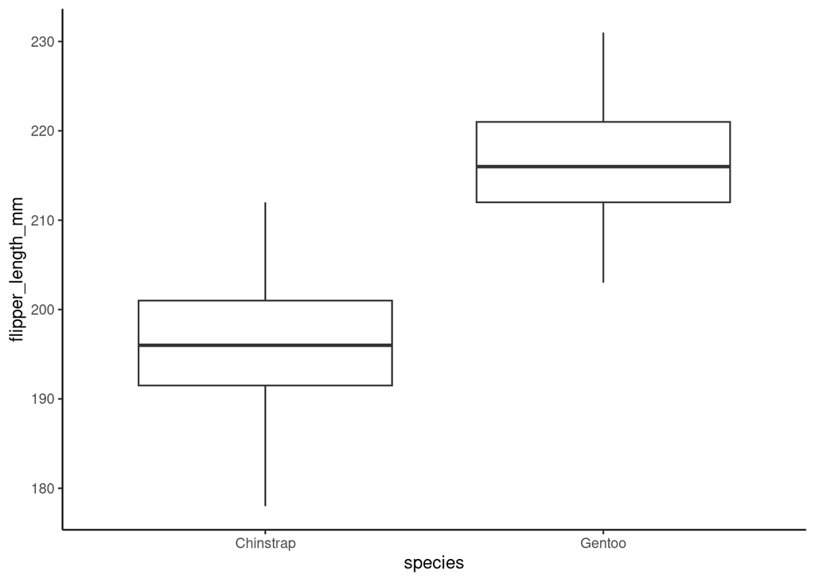

```r
# could instead do a density plot or histogram too!
penguins %>%
  ggplot(aes(y = flipper_length_mm, x = species)) +
  geom_boxplot() +
  theme_classic()
```

## Review Exercise 2: model the bivariate relationships

Let’s fit 2 simple linear regression models of `flipper_length_mm` by penguin `bill_length_mm` and `species`:

```r
summary(lm(flipper_length_mm ~ bill_length_mm, penguins))
```

```
Call:
lm(formula = flipper_length_mm ~ bill_length_mm, data = penguins)

Residuals:
    Min      1Q  Median      3Q     Max
-30.441 -10.998   3.015   8.942  19.881

Coefficients:
               Estimate Std. Error t value Pr(>|t|)
(Intercept)    177.4971    13.6676  12.987   <2e-16 ***
bill_length_mm   0.6712     0.2850   2.355   0.0195 *
---
Signif. codes:  0 '***' 0.001 '**' 0.01 '*' 0.05 '.' 0.1 ' ' 1

Residual standard error: 11.91 on 187 degrees of freedom
Multiple R-squared:  0.02881,   Adjusted R-squared:  0.02362
F-statistic: 5.548 on 1 and 187 DF,  p-value: 0.01954
```

**Review:** How do we interpret the `bill_length_mm` coefficient from this model?

```r
summary(lm(flipper_length_mm ~ species, penguins))
```

```
Call:
lm(formula = flipper_length_mm ~ species, data = penguins)

Residuals:
    Min      1Q  Median      3Q     Max
-18.045  -5.045  -1.045   3.955  15.955

Coefficients:
              Estimate Std. Error t value Pr(>|t|)
(Intercept)   196.0448     0.8065  243.07   <2e-16 ***
speciesGentoo  21.0372     1.0039   20.96   <2e-16 ***
---
Signif. codes:  0 '***' 0.001 '**' 0.01 '*' 0.05 '.' 0.1 ' ' 1

Residual standard error: 6.602 on 187 degrees of freedom
Multiple R-squared:  0.7014,    Adjusted R-squared:  0.6998
F-statistic: 439.2 on 1 and 187 DF,  p-value: < 2.2e-16
```

**Review:** How do we interpret the intercept and `speciesGentoo` coefficient from this model?

> Intercept: the expected flipper length for Chinstrap penguins is 196mm.

What do these visualizations and models tell us? Do you think it would be useful to consider both bill length *and* species as predictors?

> Both bill length and species appear to be associated with flipper length–perhaps we should try to model these both simultaneously!

## Exercise 3: Visualizing the model

We’ve learned how to visualize the relationship of `flipper_length_mm` by `bill_length_mm` alone:

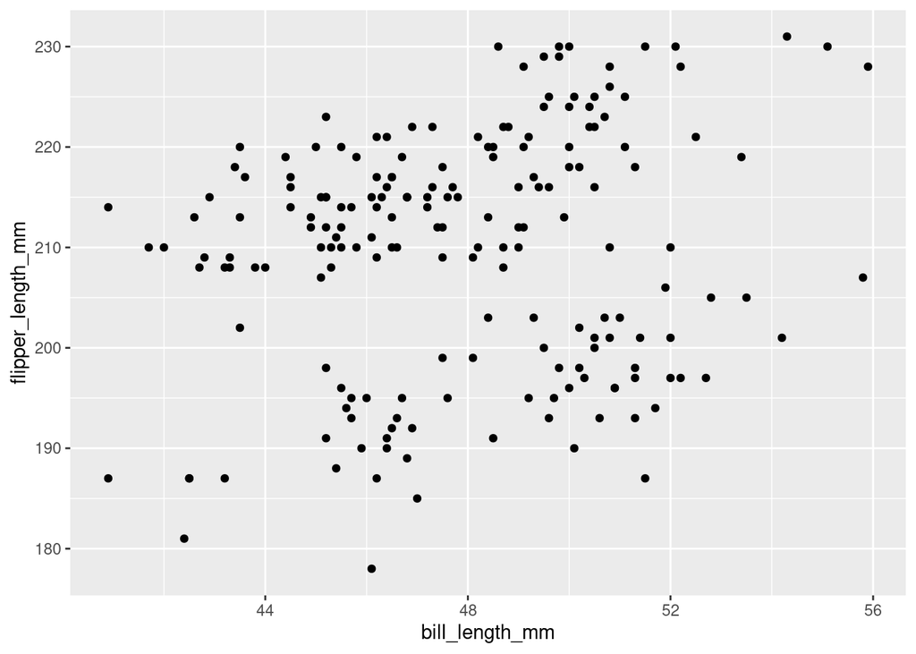

```r
penguins %>%
  ggplot(aes(y = flipper_length_mm, x = bill_length_mm)) +
  geom_point()
```

1. THINK: How might we change the scatterplot points to *also* indicate information about penguin `species`? (There’s more than 1 approach!)

> Use the categorical `species` variable as a color aesthetic
2. Try out your idea by modifying the code below. If you get stuck, talk with the tables around you!

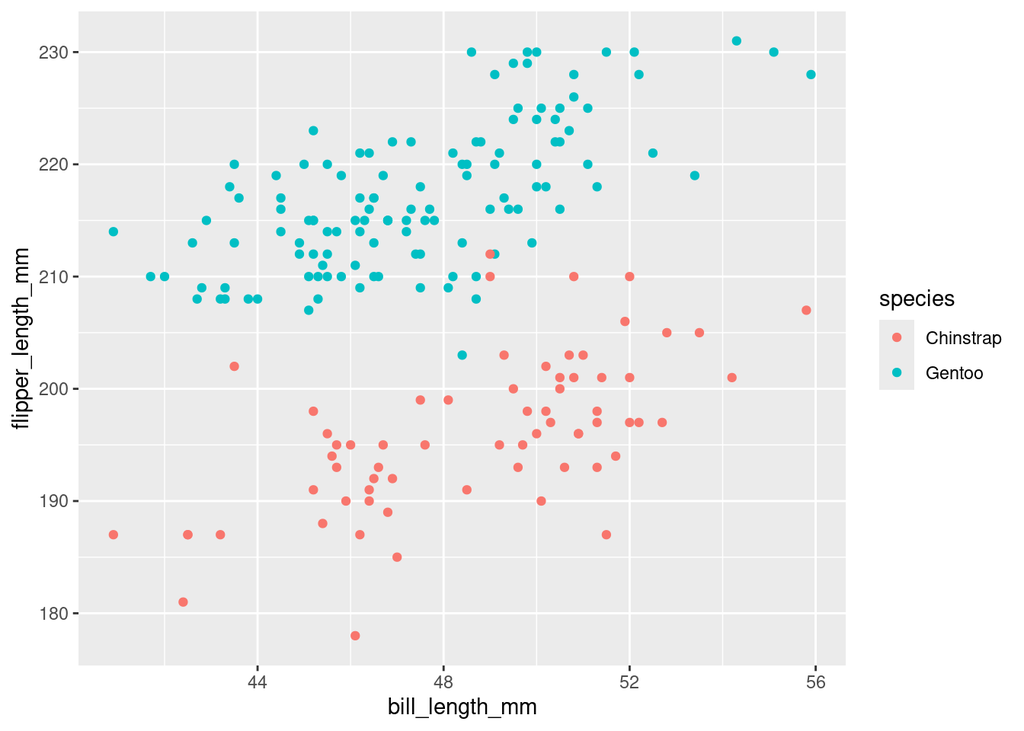

```r
# instead of colour = species, could also use shape or size
penguins %>%
  ggplot(aes(y = flipper_length_mm, x = bill_length_mm, colour = species)) +
  geom_point()
```

3. THINK: Reflect on this plot–how do you think a *multiple* regression model of `flipper_length_mm` using *both* of these predictors would be represented?

> perhaps separate lines of best fit for each of the species
2. Check your intuition below by modifying the code below to include `species` in this plot, as you did in Exercise 1.

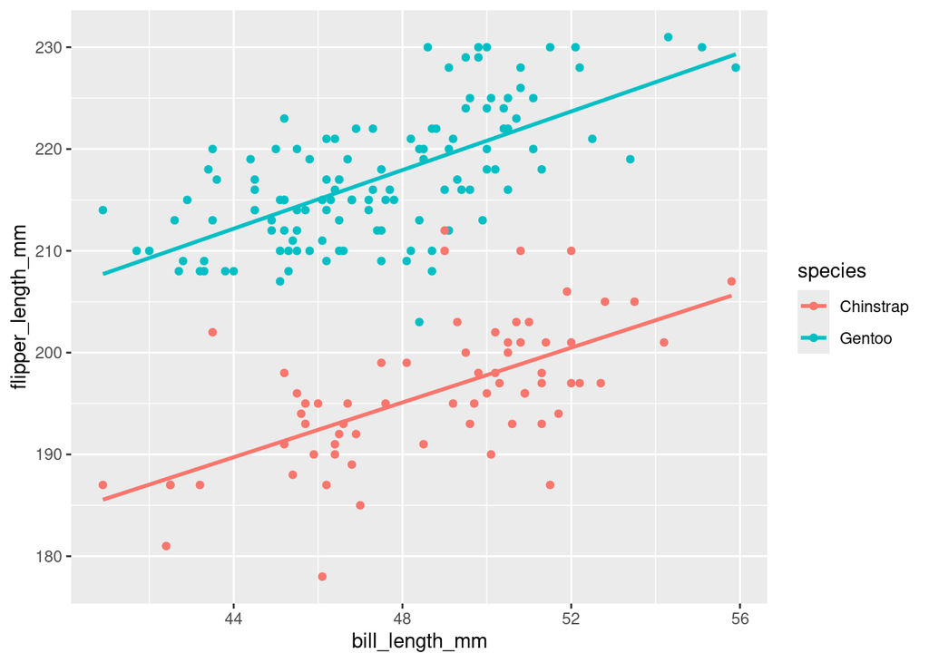

```r
penguins %>%
  ggplot(aes(y = flipper_length_mm, x = bill_length_mm, colour = species)) +
  geom_point() +
  geom_smooth(method = "lm", se = FALSE)
```

## Exercise 4: Intuition

1. Gentoo tend to have longer flippers.
2. Flipper length is positively associated with bill length.
3. No. the lines are parallel / have the same slopes.

## Exercise 5: Model formula

```r
# Build the model
penguin_mod <- lm(flipper_length_mm ~ bill_length_mm + species, data = penguins)

# Summarize the model
summary(penguin_mod)
```

```
Call:
lm(formula = flipper_length_mm ~ bill_length_mm + species, data = penguins)

Residuals:
     Min       1Q   Median       3Q      Max
-15.4763  -3.2260  -0.1525   3.1581  15.5303

Coefficients:
               Estimate Std. Error t value Pr(>|t|)
(Intercept)    127.7537     6.1175   20.88   <2e-16 ***
bill_length_mm   1.4024     0.1250   11.22   <2e-16 ***
speciesGentoo   22.8480     0.7938   28.78   <2e-16 ***
---
Signif. codes:  0 '***' 0.001 '**' 0.01 '*' 0.05 '.' 0.1 ' ' 1

Residual standard error: 5.112 on 186 degrees of freedom
Multiple R-squared:  0.8219,    Adjusted R-squared:   0.82
F-statistic: 429.3 on 2 and 186 DF,  p-value: < 2.2e-16
```

1. `bill_length_mm + species`
2. E[flipper_length_mm | bill_length_mm, speciesGentoo] = 127.75 + 1.40 * bill_length_mm + 22.85 * speciesGentoo

## Exercise 6: Sub-model formulas

Chinstrap: flipper_length_mm = 127.75 + 1.40 bill_length_mm

Gentoo: flipper_length_mm = (127.75 + 22.85) + 1.40 bill_length_mm = 150.6 + 1.40 bill_length_mm

## Exercise 7: coefficients – physical interpretation

1. The intercept coefficient, 127.75, is the intercept of the line for **Chinstrap** penguins.
2. The `bill_length_mm` coefficient, 1.40, is the **slope** of both lines.
3. The `speciesGentoo` coefficient, 22.85, indicates that the **intercept** of the line for Gentoo is 22.85mm higher than the **intercept** of the line for Chinstrap. Similarly, since the lines are parallel, the line for Gentoo is 22.85mm higher than the line for Chinstrap at any `bill_length_mm`.

## Exercise 8: coefficients – contextual interpretation

1. For Chinstrap penguins with 0mm bills (silly), we expect a flipper length of 127.75mm.
2. For both Chinstrap and Gentoo penguins, flipper lengths increase by 1.40mm on average for every additional mm in bill length.
3. At any `bill_length_mm`, we expect the a Gentoo penguin to have 22.85mm longer flippers than a Chinstrap, on average.

## Exercise 9: Prediction

```r
# a
127.75 + 1.40*50 + 22.85*0
```

```
[1] 197.75
```

```r
# b
127.75 + 1.40*50 + 22.85*1
```

```
[1] 220.6
```

```r
# c
predict(penguin_mod,
        newdata = data.frame(bill_length_mm = 50,
                             species = "Chinstrap"))
```

```
      1
197.872
```

```r
predict(penguin_mod,
        newdata = data.frame(bill_length_mm = 50,
                             species = "Gentoo"))
```

```
       1
220.7201
```

## Exercise 10: R-squared

1. species
2. no wrong answer
3. It’s higher than the R-squared when we use either predictor alone!

# More practice

```r
# Load packages & import data
library(readr)
library(ggplot2)
library(dplyr)

bikes <- read_csv("https://mac-stat.github.io/data/bikeshare.csv") %>%
  rename(rides = riders_registered)
```

## Exercise 1: Review visualization

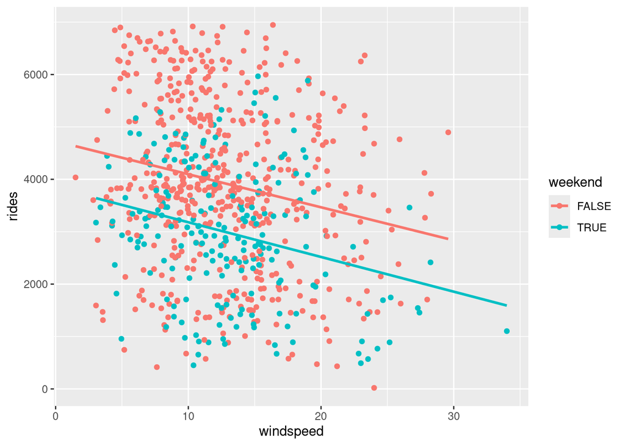

```r
bikes %>%
  ggplot(aes(y = rides, x = windspeed, color = weekend)) +
  geom_point() +
  geom_smooth(method = "lm", se = FALSE)
```

## Exercise 2: Review model

weekdays: rides = 4738.38 - 63.97 windspeed

weekends: rides = 4738.38 - 63.97 windspeed - 925.16 = 3813.22 - 63.97 windspeed

## Exercise 3: Review coefficient interpretation

1. We expect an average of 4738 riders on **weekdays with 0 windspeed**.
2. On average, we expect a 1mph increase in windspeed to be associated with 64 fewer riders, controlling for weekend status.
3. On average, we expect 925 fewer riders on weekend days than on weekends, controlling for windspeed.

## Exercise 4: 2 categorical predictors – visualization

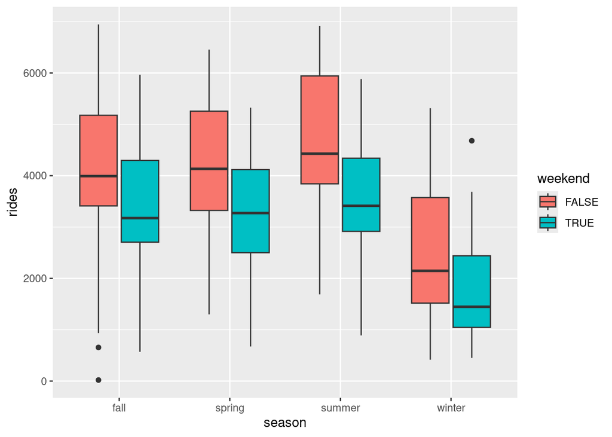

```r
bikes %>%
  ggplot(aes(y = rides, x = season, fill = weekend)) +
  geom_boxplot()
```

## Exercise 5: follow-up

1. In every season, ridership tends to be lower on weekends. Across weekend status, ridership tends to be highest in summer and lowest in winter.
2. 8 expected outcomes

## Exercise 6: 2 categorical predictors – build the model

```r
#fall weekday:
4260.45 - 912.33*0 - 116.38*0 + 438.44*0 - 1719.06*0
```

```
[1] 4260.45
```

```r
#winter weekday:
4260.45 - 912.33*0 - 116.38*0 + 438.44*0 - 1719.06*1
```

```
[1] 2541.39
```

```r
#fall weekend:
4260.45 - 912.33*1 - 116.38*0 + 438.44*0 - 1719.06*0
```

```
[1] 3348.12
```

```r
#winter weekend:
4260.45 - 912.33*1 - 116.38*0 + 438.44*0 - 1719.06*1
```

```
[1] 1629.06
```

2. 8: 2 weekend categories * 4 season categories

## Exercise 7: 2 categorical predictors – interpret the model

1. We expect there to be, on average, 4260 riders on **weekdays** during the **fall**.
2. On average, we expect there to be 912 fewer riders on weekends than on weekends, adjusting for season.
3. On average, we expect there to be 1719 fewer riders in winter than in fall, adjusting for weekday status.

## Exercise 8: 2 quantitative predictors – visualization

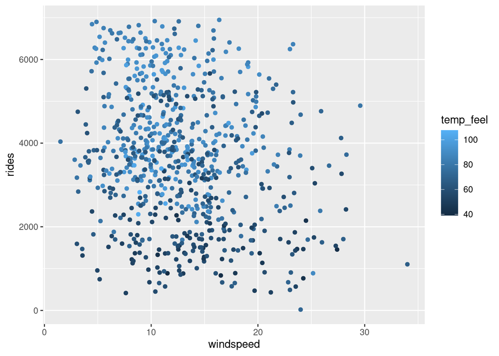

```r
bikes %>%
  ggplot(aes(y = rides, x = windspeed, color = temp_feel)) +
  geom_point()
```

## Exercise 9: follow-up

Ridership tends to increase with temperature (no matter the windspeed) and decrease with windspeed (no matter the temperature).

## Exercise 10: 2 quantitative predictors – modeling

1. -24.06 = average ridership on days with 0 windspeed and a 0 degree temperature. (Note: this is a *correct* interpretation, even though it doesn’t make conceptual sense! The model doesn’t know that ridership can’t be negative!)
2. On average, we expect a 1mph increase in windspeed to be associated with 37 fewer riders on a given day, adjusting for temperature.
3. On average, we expect a 1 degree increase in temperature to be associated with 56 more riders on a given day, adjusting for windspeed.

## Exercise 11: Which is best?

1. model 2
2. temperature
3. R-squared increases (our model is stronger when we include another predictor)
4. nope. model 1 (with windspeed and weekend) has a lower R-squared than model 5 (with only temperature)

## Exercise 13: Practice 1

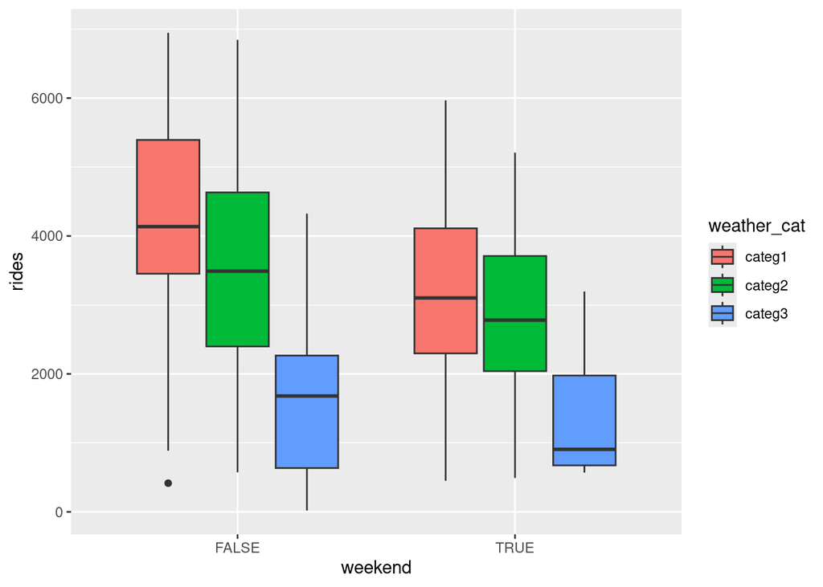

```r
bikes %>%
  ggplot(aes(y = rides, x = weekend, fill = weather_cat)) +
  geom_boxplot()
```

```r
new_model_1 <- lm(rides ~ weekend + weather_cat, bikes)
coef(summary(new_model_1))
```

```
                    Estimate Std. Error   t value      Pr(>|t|)
(Intercept)        4211.8741   75.54724 55.751529 9.461947e-265
weekendTRUE        -982.2106  117.24719 -8.377264  2.786301e-16
weather_catcateg2  -608.8640  113.00211 -5.388077  9.628947e-08
weather_catcateg3 -2360.2049  319.71640 -7.382183  4.270163e-13
```

- The average ridership on a *weekday* with *nice* weather (categ1) is 4212 rides.
- On days with the same weather, we expect on average 982 rides less on a weekend than on a weekday.
- On average, we expect ridership to be 609 rides less on dreary days than when the weather is nice, controlling for day of the week.

## Exercise 14: Practice 2

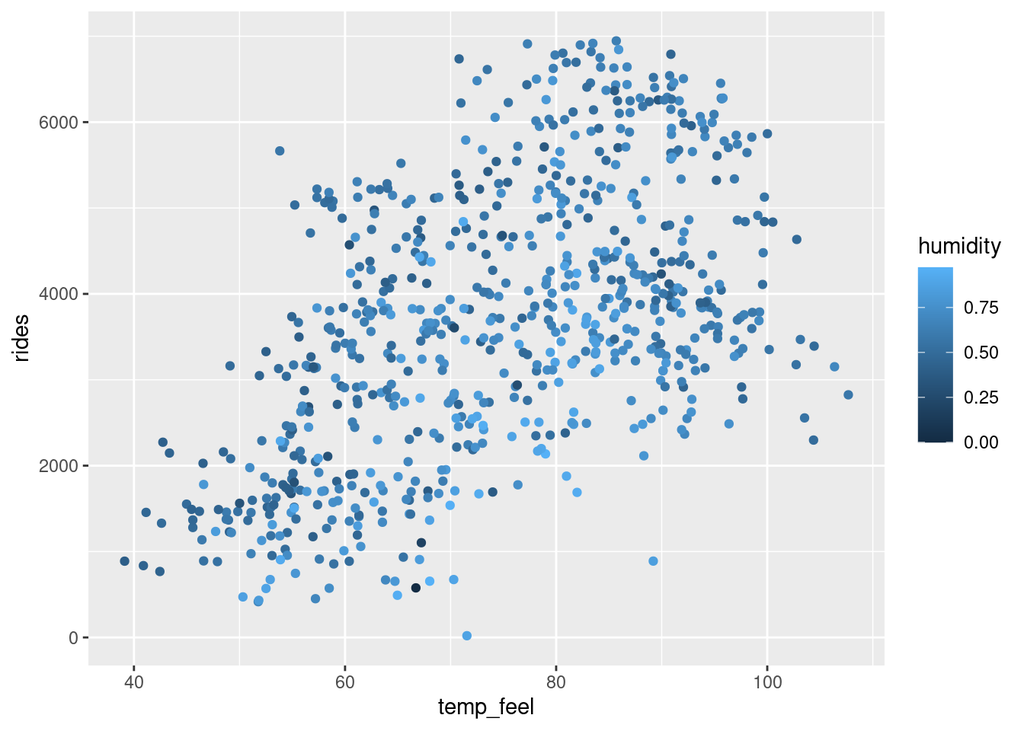

```r
bikes %>%
  ggplot(aes(y = rides, x = temp_feel, color = humidity)) +
    geom_point()
```

```r
new_model_2 <- lm(rides ~ temp_feel + humidity, bikes)
coef(summary(new_model_2))
```

```
               Estimate Std. Error   t value     Pr(>|t|)
(Intercept)   315.83704 303.777334  1.039699 2.988249e-01
temp_feel      60.43316   3.272315 18.468015 9.451345e-63
humidity    -1868.99356 336.963661 -5.546573 4.078901e-08
```

- On average, we expect 316 riders on days that feel like 0 degrees with no humidity.
- On average, we expect a 1 degree increase in ridership to be associated with a 60 ride increase in ridership, for days with the same humidity.
- On average, we expect a 0.1 increase in humidity levels to be associated with a decrease in ridership by 187 rides, for days with the same temperature.

## Exercise 15: Practice 3

```r
new_model_3 <- lm(rides ~ temp_feel + weather_cat, bikes)
coef(summary(new_model_3))
```

```
                     Estimate Std. Error   t value     Pr(>|t|)
(Intercept)        -288.68840 251.264383 -1.148943 2.509574e-01
temp_feel            55.30133   3.215495 17.198387 7.082670e-56
weather_catcateg2  -386.42241 100.187725 -3.856984 1.249775e-04
weather_catcateg3 -1919.01375 283.022420 -6.780430 2.481218e-11
```

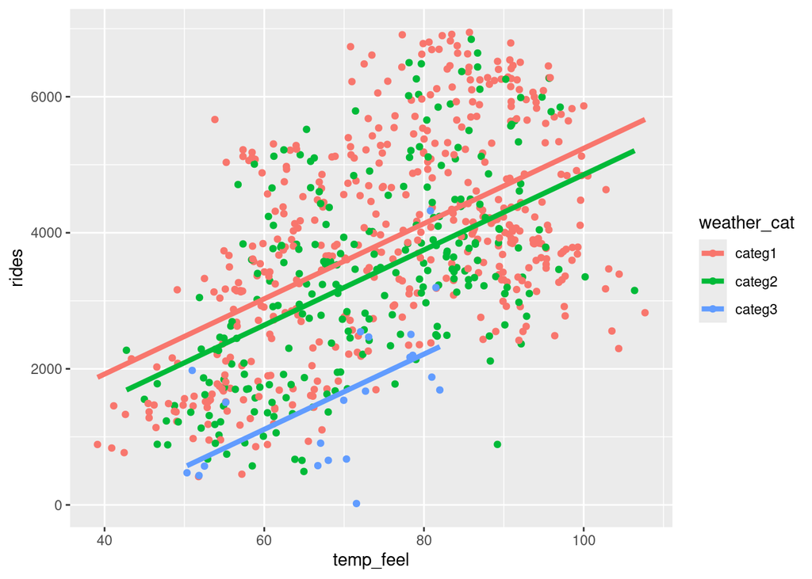

```r
bikes %>%
  ggplot(aes(y = rides, x = temp_feel, color = weather_cat)) +
  geom_point() +
  geom_line(aes(y = new_model_3$fitted.values), size = 1.5)
```

- We expect an average of -289 riders on nice weather days that feel like 0 degrees. (Note: this is a *correct* interpretation, even though it doesn’t make conceptual sense!)
- On average, we expect a 1 degree increase in temperature to be associated with a 55 ride increase, for days with the same weather.
- On average, we expect the number of rides to be 386 rides lower on a dreary weather day compared to a nice weather day, for days with the same temperature.

## Exercise 16: CHALLENGE

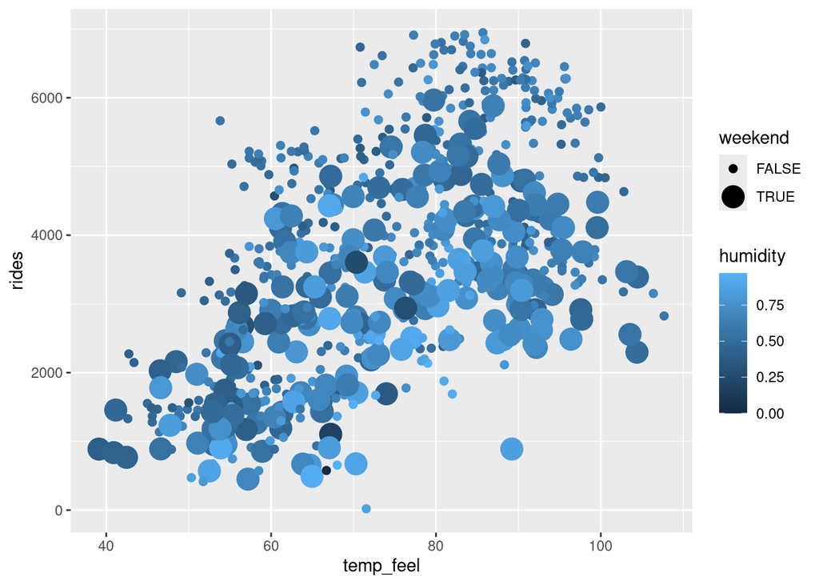

```r
bikes %>%
  ggplot(aes(y = rides, x = temp_feel, color = humidity, size = weekend)) +
  geom_point()
```

```r
new_model_4 <- lm(rides ~ temp_feel + humidity + weekend, bikes)
coef(summary(new_model_4))
```

```
               Estimate Std. Error   t value     Pr(>|t|)
(Intercept)   668.60236 292.181063  2.288315 2.240530e-02
temp_feel      59.36751   3.119256 19.032585 7.626695e-66
humidity    -1906.43437 320.982938 -5.939364 4.433789e-09
weekendTRUE  -869.05771 100.057822 -8.685555 2.471050e-17
```

- We expect an average of 669 riders on weekdays that feel like 0 degrees, and have no humidity.
- On average, we expect a 1 degree increase in temperature to be associated with a 59 ride increase in ridership, for days with the same humidity levels and time of the week.
- On average, we expect a 0.1 point increase in humidity levels to be associated with a 190.6 ride decrease in ridership, for days with the same temperature and time of the week.
- On average, we expect ridership to be 869 rides lower on weekends compared to weekdays, controlling for temperature and humidity.